# Final Project

Yotam Nir

18.07.2021

### 1. Introduction of the Paper

This project replicates and extends “Jewish Persecutions and Weather Shocks: 1100-1800” (Anderson, Johnson and Koyama 2017). This paper attempts to shed light on the relationship between economic shocks and the persecution of Jews in Europe of 1100-1800 by observing local temperature deviations. These deviations are used as a proxy for economic prosperity as they are highly correlated with agricultural output – the main source of income in the historical setting in question as well as a central consumption good, with the vast majority of the population consistently malnourished and consuming around the subsistence level. The authors suggest that economic shocks increase the persecution of Jews by functioning as an increase in the local ruler’s discounting of future periods. The game analogous to this interaction is of an indefinitely repeated prisoner’s dilemma, where the ruler’s discount factor is exposed to stochastic shocks which may bring it below the cooperation threshold level. In more stable periods, the ruler can commit to protecting Jews and enforcing their property rights and thus benefit from their credit services in the long run. But in less stable periods, seizing their property and diverting popular unrest towards Jews becomes more worthwhile.

The authors find that a one standard deviation decrease from the average growing season temperature in a particular locality increases the probability of persecution (defined as pogroms or expulsions) in that locality by about one percent – a significant increase from a baseline of a 2 percent probability. They also find that more stable regimes were less sensitive to weather shocks – a result in line with their proposed mechanism. Additionally, they find that the relationship between weather shocks and persecutions gradually decreased between 1500 and 1800 – a result that they attribute to improved market integration on the continent reducing the exposure of local economies to local weather shocks. This project replicates and extends the main result, while the prediction section also lends credence to the argument for the significance of institutions.

### 2. Replication

#### 2.1 Data Preparation

The data for this paper can be downloaded from the Economic Journal’s website on https://academic.oup.com/ej/article/127/602/924/5069222#123999755. The authors prefer estimating the effect of the average temperature deviation over five-year intervals in order to average out significant measurement error in the historical temperature data, and have prearranged a dataset accordingly. I load this dataset here, and replicate some variables that they use.

```r
if (!require("pacman")) install.packages("pacman")
pacman::p_load(
  tidyverse,
  tidymodels,
  broom,
  fastDummies,   # for turning categorical variables into sets of dummies
  fixest,        # for convenient fixed effects estimation and standard error clustering
  hdm,           # for double lasso
  stacks,        # for optimally averaging model predictions
  NeuralNetTools # for displaying nnet results
)

# Importing the data and constructing variables
fiveyear <- read.csv("Base Five Year Panel.csv") %>%
  as_tibble() %>%
  group_by(id) %>%
  mutate(
    lag1temperature  = lag(temperature, 1),
    lag2temperature  = lag(temperature, 2),
    lag3temperature  = lag(temperature, 3),
    lead1temperature = lead(temperature, 1),
    lead2temperature = lead(temperature, 2),
    lead3temperature = lead(temperature, 3)
  ) %>%
  ungroup() %>%
  filter(sample == 1 & !is.na(lag1temperature)) %>%
  mutate(    # soil suitability for wheat growth and institutional variables:
    lowsuitability = as.numeric(wheat150suit < mean(wheat150suit)),
    lowsuitXlag1temp = lowsuitability*lag1temperature,
    wheat150suitXlag1temperature = wheat150suit*lag1temperature,
    lowconstraint = as.numeric(ajrconstraint< mean(ajrconstraint)),
    lowconstraintXlag1temperature = lowconstraint*lag1temperature,
    lowcapital = as.numeric(ajrcapital< mean(ajrcapital)),
    lowcapitalXlag1temperature = lowcapital*lag1temperature,
    lowantiquity = as.numeric(stateantiquity < mean(stateantiquity)),
    lowantiquityXlag1temperature = lowantiquity*lag1temperature,
    persecutions = persecutions * 100 # for percent rather than decimal coefficients
  )
```

#### 2.2 Econometric Specification

The main specification is the fixed effects regression of city by five-year interval given below:

$$y_{it} = \beta T_{i,t-1} + \eta_i + \mu_t +X_{it}\Omega + \epsilon_{it}$$

The outcome is a binary indicator for whether a persecution took place in city $i$ in period $t$, with the treatment being the average degrees Celsius deviation in the previous five years’ growing season temperature from the city average. The regression also controls for population density and for the black death (controlling for both intercept and slope).

The authors cluster the standard errors by temperature grids. These grids are the various sources of the historical temperature data, from which the local temperatures are then computed. Since they provide quite noisy estimates, it makes sense to cluster localities whose temperatures are influenced by the same noise.

#### 2.3 Results

The paper’s main result is reproduced below (note: the `fiveyear` variable is explicitly given dummies here just for technical reasons, to prevent `plague` from being omitted due to collinearity with the year fixed effects).

```r
# Panel A: Baseline effect of temperature on persecutions
feols(persecutions ~ lag1temperature + popdensity + plague + slopeplague + factor(fiveyear) | id , data = fiveyear, cluster = "grid")
```

```
## OLS estimation, Dep. Var.: persecutions
## Observations: 55,698
## Fixed-effects: id: 933
## Standard-errors: Clustered (grid)
##                       Estimate Std. Error   t value Pr(>|t|))
## lag1temperature      -3.194500   1.058500 -3.017900  0.005374 **
## popdensity           -0.025077   0.029909 -0.838461  0.408873
## plague                6.682500   3.314900  2.015900  0.053495 .
## slopeplague          38.453000  11.458000  3.356000  0.002288 **
## factor(fiveyear)1110 -0.644507   0.510692 -1.262000  0.217350
## factor(fiveyear)1116  0.805352   0.644286  1.250000  0.221649
## factor(fiveyear)1120 -0.787210   0.535766 -1.469300  0.152894
## factor(fiveyear)1126 -0.190348   0.688550 -0.276447  0.784235
## ... 133 coefficients remaining (display them with summary() or use argument n)
## ... 1 variable was removed because of collinearity (factor(fiveyear)1350)
## ---
## Signif. codes:  0 '***' 0.001 '**' 0.01 '*' 0.05 '.' 0.1 ' ' 1
## RMSE: 13.9     Adj. R2: 0.103348
##              Within R2: 0.100962
```

```r
# Panel B: Excluding the Iberian national expulsion
feols(persecutions ~ lag1temperature + popdensity + plague + slopeplague + factor(fiveyear) | id , data = fiveyear %>% filter(nat1492 != 1 & nat1497 != 1), cluster = "grid")
```

```
## OLS estimation, Dep. Var.: persecutions
## Observations: 55,253
## Fixed-effects: id: 933
## Standard-errors: Clustered (grid)
##                       Estimate Std. Error   t value Pr(>|t|))
## lag1temperature      -1.597900   0.536625 -2.977700  0.005936 **
## popdensity           -0.023403   0.028439 -0.822916  0.417509
## plague                6.913300   3.354000  2.061200  0.048680 *
## slopeplague          36.021000  11.417000  3.155000  0.003815 **
## factor(fiveyear)1110 -0.801668   0.554287 -1.446300  0.159194
## factor(fiveyear)1116 -0.075302   0.576715 -0.130570  0.897049
## factor(fiveyear)1120 -0.886718   0.562154 -1.577400  0.125946
## factor(fiveyear)1126 -0.359805   0.730674 -0.492429  0.626255
## ... 132 coefficients remaining (display them with summary() or use argument n)
## ... 1 variable was removed because of collinearity (factor(fiveyear)1350)
## ---
## Signif. codes:  0 '***' 0.001 '**' 0.01 '*' 0.05 '.' 0.1 ' ' 1
## RMSE: 13.3     Adj. R2: 0.0847
##              Within R2: 0.079762
```

This is virtually identical to the authors’ preferred Regression 3 in Table 1:

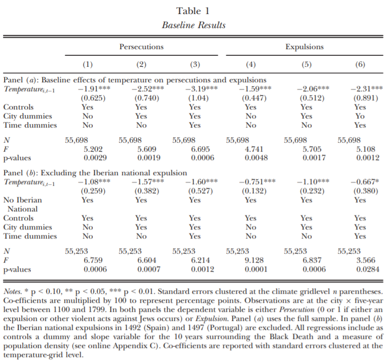

What we have found is that a one degree Celsius decrease from the average growing season temperature increases the likelihood of persecution by around 3 percent, which is very large relative to a baseline probability of 2 percent. However, a one degree Celsius deviation from the average temperature is a very large deviation – if we translate this to a one standard deviation change, which is approximately a third of a degree Celsius, we get that such a change increases the likelihood of persecution by around one percent.

As discussed below, it is perhaps odd that the authors select this result rather than their smaller result from Panel B, which removes the less than 1 percent of the sample that suffered the Iberian national expulsions of 1492 and 1497 and sees the effect cut in half, or that they do not at least control for these expulsions in Panel A.

### 3. Extension – Double Lasso

(Remarks: here and in the second procedure I perform the procedure twice – once using the partialling out method and once using the double selection method. Their results are unsurprisingly similar. Additionally, I prevent the double lasso procedure from selecting any controls affected by the treatment – “bad controls” in the language of Angrist and Pischke. Thus, for example, all interactions with lagged temperature are omitted, and so is contemporaneous temperature. The omission of the latter may appear more controversial, but it is found to be insignificant in any case.)

```r
# Demeaning the non-constant variables for a fixed-effects double lasso
fiveyear_FE <- demean(X = fiveyear %>%
                        select(persecutions, slopeplague, popdensity, stateantiquity, ajrcapital, ajrconstraint, nat1492, nat1497, starts_with("lag"), lowconstraint, lowcapital, lowantiquity),
                      f = fiveyear %>%
                        select(id, fiveyear))

# Double Lasso with Fixed Effects
y_FE <- fiveyear_FE$persecutions
d_FE <- fiveyear_FE$lag1temperature
x_FE <- fiveyear_FE %>%
  select(-persecutions, -lag1temperature) %>%
  as.matrix()
partial_out_FE <- rlassoEffect(x_FE, y_FE, d_FE, method = "partialling out")
double_selection_FE <- rlassoEffect(x_FE, y_FE, d_FE, method = "double selection")
```

```r
summary(partial_out_FE)
```

```
## [1] "Estimates and significance testing of the effect of target variables"
##      Estimate. Std. Error t value Pr(>|t|)
## [1,]   -2.1300     0.3932  -5.417 6.05e-08 ***
## ---
## Signif. codes:  0 '***' 0.001 '**' 0.01 '*' 0.05 '.' 0.1 ' ' 1
```

```r
summary(double_selection_FE)
```

```
## [1] "Estimates and significance testing of the effect of target variables"
##    Estimate. Std. Error t value Pr(>|t|)
## d1   -2.1300     0.4019  -5.299 1.16e-07 ***
## ---
## Signif. codes:  0 '***' 0.001 '**' 0.01 '*' 0.05 '.' 0.1 ' ' 1
```

We have obtained a smaller, but still significant, effect. The difference is mostly attributable to the double lasso’s addition of controls for the Iberian national expulsions.

The second procedure is performed on the original, not demeaned sample, but with dummy variables for each city and for each time period. This allows the lasso procedure to opt not to select the controls imposed by the city and five-year fixed effects if the between variation does not generate much noise. As discussed in the previous paragraph, this is less interesting when our goal is the measurement of a causal effect, rather than prediction. In any case, the result strongly validates the use of fixed effects, as it selects a very large amount of the fixed effect dummies despite the lasso penalty. 288 out of 933 city dummies are selected (i.e. 31 percent – a larger amount than I would have expected given the penalty involved), and 126 out of 139 time dummies are selected (i.e. 91 percent).

```r
# Double Lasso with dummies for city and five-year period, not demeaned
y <- fiveyear$persecutions
d <- fiveyear$lag1temperature
x <- fiveyear %>%
  dummy_cols(select_columns = c("id", "fiveyear")) %>%   # creating dummies for city ID
  select(slopeplague, popdensity, stateantiquity, ajrcapital, ajrconstraint, nat1492, nat1497, lag2temperature, lag3temperature, lowconstraint, lowcapital, lowantiquity, starts_with("id_"), starts_with("fiveyear_")) %>%
  as.matrix()
partial_out <- rlassoEffect(x, y, d, method = "partialling out")
double_selection <- rlassoEffect(x, y, d, method = "double selection")
```

```r
summary(partial_out)
```

```
## [1] "Estimates and significance testing of the effect of target variables"
##      Estimate. Std. Error t value Pr(>|t|)
## [1,]   -2.3204     0.3946   -5.88 4.11e-09 ***
## ---
## Signif. codes:  0 '***' 0.001 '**' 0.01 '*' 0.05 '.' 0.1 ' ' 1
```

```r
summary(double_selection)
```

```
## [1] "Estimates and significance testing of the effect of target variables"
##    Estimate. Std. Error t value Pr(>|t|)
## d1    -2.326      0.404  -5.758 8.54e-09 ***
## ---
## Signif. codes:  0 '***' 0.001 '**' 0.01 '*' 0.05 '.' 0.1 ' ' 1
```

The methodological tension between the two approaches is thus avoided in this instance, as the results are very similar to the estimation above and again significant.

The takeaway from this section is that – apart from the omission of controls for the Iberian national expulsions – the authors’ results are quite robust to additional variable selection by double lasso. To illustrate this, note that once we omit the Iberian expulsion variables, we get treatment effects quite close to, and even larger than, that presented by the authors:

```r
summary(rlassoEffect(x_FE[,-c(6:7)], y_FE, d_FE, method = "partialling out"))
```

```
## [1] "Estimates and significance testing of the effect of target variables"
##      Estimate. Std. Error t value Pr(>|t|)
## [1,]   -3.6816     0.4026  -9.146   <2e-16 ***
## ---
## Signif. codes:  0 '***' 0.001 '**' 0.01 '*' 0.05 '.' 0.1 ' ' 1
```

```r
summary(rlassoEffect(x_FE[,-c(6:7)], y_FE, d_FE, method = "double selection"))
```

```
## [1] "Estimates and significance testing of the effect of target variables"
##    Estimate. Std. Error t value Pr(>|t|)
## d1   -3.6818     0.4249  -8.665   <2e-16 ***
## ---
## Signif. codes:  0 '***' 0.001 '**' 0.01 '*' 0.05 '.' 0.1 ' ' 1
```

```r
summary(rlassoEffect(x[,-c(6:7)], y, d, method = "partialling out"))
```

```
## [1] "Estimates and significance testing of the effect of target variables"
##      Estimate. Std. Error t value Pr(>|t|)
## [1,]    -3.864      0.404  -9.566   <2e-16 ***
## ---
## Signif. codes:  0 '***' 0.001 '**' 0.01 '*' 0.05 '.' 0.1 ' ' 1
```

```r
summary(rlassoEffect(x[,-c(6:7)], y, d, method = "double selection"))
```

```
## [1] "Estimates and significance testing of the effect of target variables"
##    Estimate. Std. Error t value Pr(>|t|)
## d1   -3.8763     0.4269   -9.08   <2e-16 ***
## ---
## Signif. codes:  0 '***' 0.001 '**' 0.01 '*' 0.05 '.' 0.1 ' ' 1
```

An argument might be made that the set of available controls is not sufficiently large to make the double-lasso procedure convincing. While I have some sympathy for this argument, I think this set of variables does a good job of reflecting the institutional and environmental climate in each city. Moreover, the stability of the treatment effect given the omission of many city dummies also provides some weak support to the result’s robustness.

### 4. Prediction

I first split the data into train and test sets 80:20 (17,401 and 4,351 observations, respectively), and further split the training set into five folds. For this exercise, I am of course generally happy to allow variables to be selected even if they clearly lack *causal* importance, but I do need to remove two variables. One is the expulsions variable, as it is one of the two events that define the persecution variable in the first place and is therefore uninformative. The other is the Jewish community proportion variable, as it is to some extent an outcome of the outcome variable. If we are seeking to guess historical events for the unusual event in which we lack documentation of persecutions but do have Jewish population data, then this is fine. But if we seek to predict in the truer sense of the word, then this variable is unhelpful.

Additionally, I add variables for $temperature^2$ and $temperature^3$ in order to allow the degree of the effect of temperature to vary with the size and direction of the deviation. I also convert the outcome to a factor variable and the year variable to numeric, and create a $year^2$ variable to capture any varying time trends. I am not very concerned about the polynomial variables resulting in an overfit because of the large size of the dataset relative to the number of variables.

Finally, due to a technical issue with fitting the data for the different engines used in creating the model specifications, I create dummy variables manually from the categorical variables (country, century, and grid) rather than using the `step_dummy` function. Regrettably, I am obliged to omit the ID variable as the models fail to handle the large number of categories. The presence of country and grid categories, as well as the continuous longitude and latitude variables, go a decent way towards compensating for its absence.

```r
set.seed(1000)
split <- fiveyear %>%
    select(-expulsions, -jewishcomm50) %>%
    mutate(
        temperature2 = temperature^2,
        temperature3 = temperature^3,
        persecutions = as.factor(persecutions),
        fiveyear = as.numeric(fiveyear),
        fiveyear2 = fiveyear^2
    ) %>%
    dummy_cols(select_columns = c("country", "century", "grid")) %>%
    select(-c("id", "country", "century", "grid")) %>%
    na.omit() %>%
    initial_split(prop = 0.8)
train <- training(split)
test <- testing(split)
folds <- train %>% vfold_cv(v = 5)
```

#### Creating and examining the different model types

I use the `stacks` package to train a variety of models and average their predictions. To this end, I create sets of models, using `parsnip`, of several types – lasso, ridge, random forest, gradient boosting, and neural network – which I then combine with `stacks`.

In terms of relationships between variables, much of the work has already been done for me by the authors, who have included (with well-reasoned justifications) interactions between a large proportion of the variables which they use for their robustness checks. I add an interaction of the rainfall data with population density, under the assumption that more populous cities are more vulnerable to droughts.

```r
# Specifying the general recipe
general_rec <- recipe(persecutions ~ ., data = train) %>%
  step_zv(all_predictors()) %>%
  step_interact(~ rainfall:popdensity) %>%
  step_dummy(all_nominal_predictors())
```

##### Lasso

```r
# Lasso model definition
lasso_spec <- logistic_reg() %>%
  set_args(penalty = tune(), mixture = 1) %>%
  set_engine("glmnet") %>%
  set_mode("classification")
# Regression (both Lasso and Ridge) recipe
reg_rec <- general_rec %>%
  step_normalize(all_numeric(), skip = TRUE)  # standardizing all variables
# Lasso workflow (adding model and recipe)
lasso_wf <- workflow() %>%
  add_model(lasso_spec) %>%
  add_recipe(reg_rec)
# Tuning penalty and mixture, and fitting to the 5-fold cv
lasso_res <- lasso_wf %>%
  tune_grid(
    resamples = folds,
    metrics = metric_set(roc_auc),
    grid = grid_latin_hypercube(penalty(), size = 20),
    control = control_stack_grid()
  )
```

```
## i The workflow being saved contains a recipe, which is 10.37 Mb in
## i memory. If this was not intentional, please set the control setting
## i `save_workflow = FALSE`.
```

```r
# Top results
lasso_res %>% show_best("roc_auc") %>% select(-n, -.config)
```

```
## # A tibble: 5 x 5
##    penalty .metric .estimator  mean std_err
##      <dbl> <chr>   <chr>      <dbl>   <dbl>
## 1 1.55e- 5 roc_auc binary     0.502 0.00162
## 2 1.28e-10 roc_auc binary     0.501 0.00136
## 3 3.49e-10 roc_auc binary     0.501 0.00136
## 4 2.73e- 9 roc_auc binary     0.501 0.00136
## 5 4.85e- 9 roc_auc binary     0.501 0.00136
```

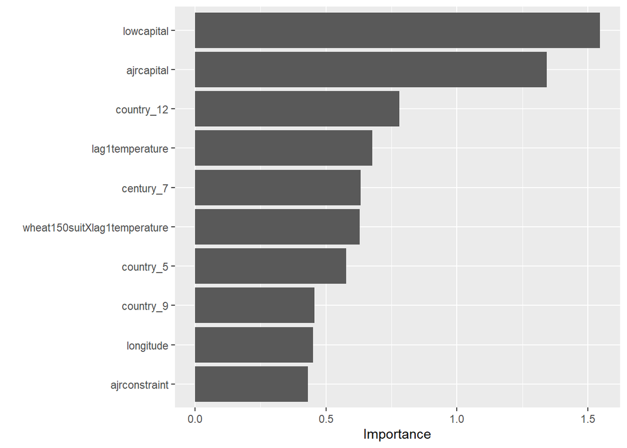

```r
# Variable importance in best by 1se model
finalize_workflow(
  lasso_wf,
  lasso_res %>% select_by_one_std_err(metric = "roc_auc", desc(penalty))
) %>%
  fit(train) %>%
  extract_fit_parsnip() %>%
  vip::vip()
```

```r
# Removing workflow object to free up memory for next parts
rm(lasso_wf)
```

##### Ridge

```r
# Ridge model definition
ridge_spec <- logistic_reg() %>%
  set_args(penalty = tune(), mixture = 0) %>%
  set_engine("glmnet") %>%
  set_mode("classification")
# Ridge workflow (adding model and recipe)
ridge_wf <- workflow() %>%
  add_model(ridge_spec) %>%
  add_recipe(reg_rec)
# Tuning penalty and mixture, and fitting to the 5-fold cv
ridge_res <- ridge_wf %>%
  tune_grid(
    resamples = folds,
    metrics = metric_set(roc_auc),
    grid = grid_latin_hypercube(penalty(), size = 20),
    control = control_stack_grid()
  )
```

```
## i The workflow being saved contains a recipe, which is 10.37 Mb in
## i memory. If this was not intentional, please set the control setting
## i `save_workflow = FALSE`.
```

```r
# Top results
ridge_res %>% show_best("roc_auc") %>% select(-n, -.config)
```

```
## # A tibble: 5 x 5
##    penalty .metric .estimator  mean std_err
##      <dbl> <chr>   <chr>      <dbl>   <dbl>
## 1 1.25e-10 roc_auc binary       0.5       0
## 2 4.37e-10 roc_auc binary       0.5       0
## 3 1.55e- 9 roc_auc binary       0.5       0
## 4 3.74e- 9 roc_auc binary       0.5       0
## 5 2.01e- 8 roc_auc binary       0.5       0
```

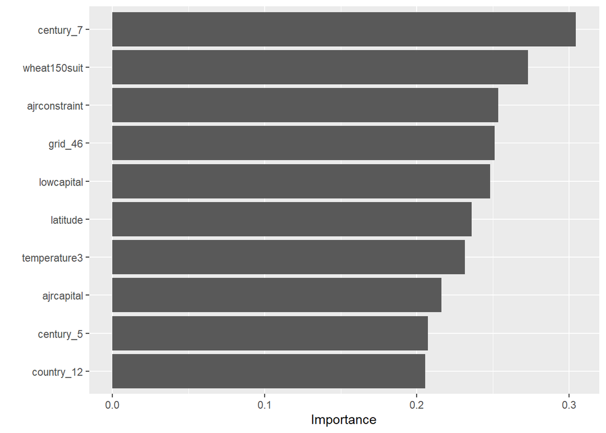

```r
# Variable importance in best by 1se model
finalize_workflow(
  ridge_wf,
  ridge_res %>% select_by_one_std_err(metric = "roc_auc", desc(penalty))
) %>%
  fit(train) %>%
  extract_fit_parsnip() %>%
  vip::vip()
```

```r
# Removing workflow object to free up memory for next parts
rm(ridge_wf)
```

##### Random Forest

```r
# Random forest model definition
rf_spec <- rand_forest(
    mtry = tune(),
    min_n = tune(),
    trees = tune()
  ) %>%
  set_mode("classification") %>%
  set_engine("randomForest")
# Random forest workflow
rf_wf <- workflow() %>%
  add_model(rf_spec) %>%
  add_recipe(general_rec)
# Tuning parameters, and fitting to the 5-fold cv
rf_res <- rf_wf %>%
  tune_grid(
    resamples = folds,
    metrics = metric_set(roc_auc),
    grid = grid_latin_hypercube(
      mtry(range = c(1L, 10L)),
      min_n(),
      trees(range = c(500L, 1500L)),
      size = 50
    ),
    control = control_stack_grid()
  )
```

```
## i The workflow being saved contains a recipe, which is 10.37 Mb in
## i memory. If this was not intentional, please set the control setting
## i `save_workflow = FALSE`.
```

```r
# Top results
rf_res %>% show_best("roc_auc") %>% select(-n, -.config)
```

```
## # A tibble: 5 x 7
##    mtry trees min_n .metric .estimator  mean std_err
##   <int> <int> <int> <chr>   <chr>      <dbl>   <dbl>
## 1     5  1366    17 roc_auc binary     0.772 0.0117
## 2     6  1243    18 roc_auc binary     0.767 0.0175
## 3     5   873     8 roc_auc binary     0.767 0.00865
## 4     5  1315     2 roc_auc binary     0.767 0.0111
## 5     4  1400    11 roc_auc binary     0.766 0.0129
```

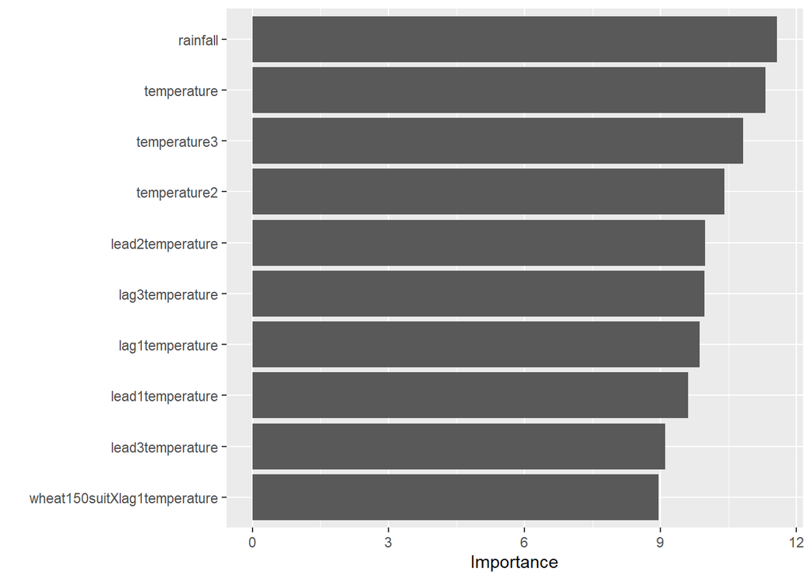

```r
# Variable importance in best model
finalize_workflow(
  rf_wf,
  rf_res %>% select_best(metric = "roc_auc")
) %>%
  fit(train) %>%
  extract_fit_parsnip() %>%
  vip::vip()
```

```r
# Removing workflow object to free up memory for next parts
rm(rf_wf)
```

##### Gradient Boosting

```r
# Boosting model definition
xgb_spec <- boost_tree(
    mtry = tune(),
    min_n = tune(),
    trees = tune(),
    tree_depth = tune(),
    learn_rate = tune(),
    loss_reduction = tune(),
    sample_size = tune()
  ) %>%
  set_mode("classification") %>%
  set_engine("xgboost")
# Boosting workflow
xgb_wf <- workflow() %>%
  add_model(xgb_spec) %>%
  add_recipe(general_rec)
# Tuning parameters, and fitting to the 5-fold cv
xgb_res <- xgb_wf %>%
  tune_grid(
    resamples = folds,
    metrics = metric_set(roc_auc),
    grid = grid_latin_hypercube(
      tree_depth(),
      min_n(),
      loss_reduction(),
      sample_size = sample_prop(range = c(0.65, 1)),
      mtry(range = c(35L, 44L)),
      trees(range = c(500L, 1500L)),
      learn_rate(),
      size = 100
    ),
    control = control_stack_grid()
  )
```

```
## i The workflow being saved contains a recipe, which is 10.37 Mb in
## i memory. If this was not intentional, please set the control setting
## i `save_workflow = FALSE`.
```

```r
# Top results
xgb_res %>% show_best("roc_auc") %>% select(-.estimator, -n, -.config, -.metric)
```

```
## # A tibble: 5 x 9
##    mtry trees min_n tree_depth learn_rate loss_reduction sample_size  mean
##   <int> <int> <int>      <int>      <dbl>          <dbl>       <dbl> <dbl>
## 1    37  1187     9         12     0.0557  0.00273             0.836 0.792
## 2    43  1461     6         10     0.0193  0.00000141          0.664 0.788
## 3    35  1198     6         12     0.0685  0.00000000640       0.890 0.785
## 4    37  1307     3         11     0.0433  0.0000000125        0.703 0.783
## 5    37   977    16          5     0.0309  0.164               0.906 0.782
## # ... with 1 more variable: std_err <dbl>
```

```r
# Variable importance in best model
finalize_workflow(
  xgb_wf,
  xgb_res %>% select_best(metric = "roc_auc")
) %>%
  fit(train) %>%
  extract_fit_parsnip() %>%
  vip::vip()
```

```
## [22:00:08] WARNING: amalgamation/../src/learner.cc:1095: Starting in XGBoost 1.3.0, the default evaluation metric used with the objective 'binary:logistic' was changed from 'error' to 'logloss'. Explicitly set eval_metric if you'd like to restore the old behavior.
```

[figure not shown]

```r
# Removing workflow object to free up memory for next parts
rm(xgb_wf)
```

##### Neural Network

```r
# NN model definition
nnet_spec <- mlp(
  hidden_units = tune(),
  penalty = tune(),
  epochs = tune()
) %>%
  set_engine("nnet") %>%
  set_mode("classification")
# NN recipe extension
nnet_rec <- general_rec %>%
  step_normalize(all_predictors()) %>%
  step_corr(all_predictors())
# NN workflow (adding model and recipe)
nnet_wf <- workflow() %>%
  add_model(nnet_spec) %>%
  add_recipe(nnet_rec)
# Tuning penalty and mixture, and fitting to the 5-fold cv
nnet_res <- nnet_wf %>%
  tune_grid(
    resamples = folds,
    metrics = metric_set(roc_auc),
    grid = grid_latin_hypercube(
      penalty(),
      hidden_units(),
      epochs(),
      size = 100
    ),
    control = control_stack_grid()
  )
```

```
## i The workflow being saved contains a recipe, which is 10.37 Mb in
## i memory. If this was not intentional, please set the control setting
## i `save_workflow = FALSE`.
```

```r
# Top results
nnet_res %>% show_best("roc_auc") %>% select(-n, -.config)
```

```
## # A tibble: 5 x 7
##   hidden_units  penalty epochs .metric .estimator  mean std_err
##          <int>    <dbl>  <int> <chr>   <chr>      <dbl>   <dbl>
## 1            7 0.142       846 roc_auc binary     0.713 0.0225
## 2            7 0.890       327 roc_auc binary     0.710 0.00908
## 3            9 0.000683    602 roc_auc binary     0.709 0.0164
## 4            5 0.544       560 roc_auc binary     0.706 0.0140
## 5            5 0.355       720 roc_auc binary     0.704 0.0132
```

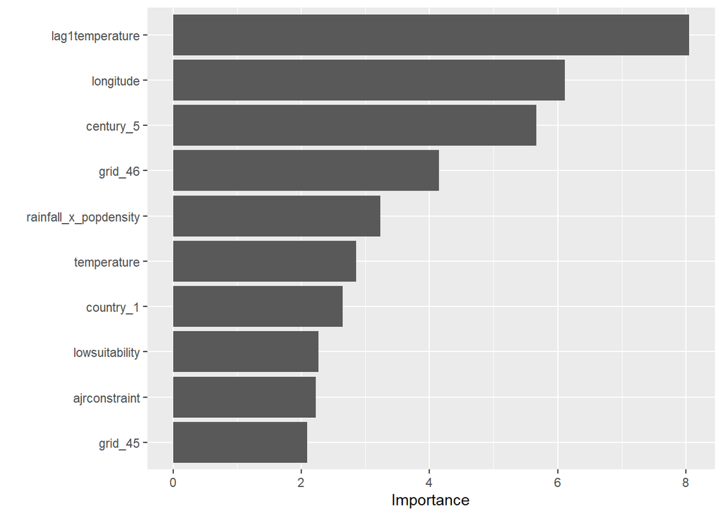

```r
# Variable importance in best by 1se model
finalize_workflow(
  nnet_wf,
  nnet_res %>% select_by_one_std_err(metric = "roc_auc", desc(penalty))
) %>%
  fit(train) %>%
  extract_fit_parsnip() %>%
  vip::vip()
```

```r
# Removing workflow object to free up memory for next parts
rm(nnet_wf)
```

#### Brief discussion of model-specific results

The explanatory variable used by the authors – `lag1temperature` – figures in the models but does not stand out especially. Temperature in other periods is given at least as much, and often more, weight. One interesting observation is that the temperature in the years following the persecution are often useful for classification. This is most likely due to the correlation of future and past deviations in temperature, which remains positive even as far as three five-year periods forward (presumably due to more prolonged climate changes). The past temperature variables may not suffice due to the significant measurement error that they include, and so perhaps future temperatures complement this data by hinting that the past temperature was not really as reported.

It is also interesting to note that the regression methods and the neural network method tend to identify specific regions and periods with more persecutions as important, as well as emphasizing institutional features of the cities (executive power, degree of capital protection, etc.) whereas the forest methods place a larger emphasis on climatic and geographic features of cities (temperatures, rainfall, and soil suitability for wheat growth). In terms of making inferences with respect to the causal model, viewing each model individually is therefore perhaps more enlightening.

It would be wrong to conclude from these results that the previous period’s temperature is not in particular important, despite its relatively lesser weight here, because temperature in general appears important and measurement error must to some extent be responsible for dulling the observed relationship. Additionally, the authors’ secondary arguments regarding the role of institutions in accentuating the effect of weather (not covered in the replication) are lent some support by the variable importance results.

#### Finalizing the model with `Stacks`

```r
stack <- stacks() %>%
  add_candidates(lasso_res) %>%
  add_candidates(ridge_res) %>%
  add_candidates(rf_res) %>%
  add_candidates(xgb_res) %>%
  add_candidates(nnet_res) %>%
  blend_predictions() %>%
  fit_members()
```

[output not shown]

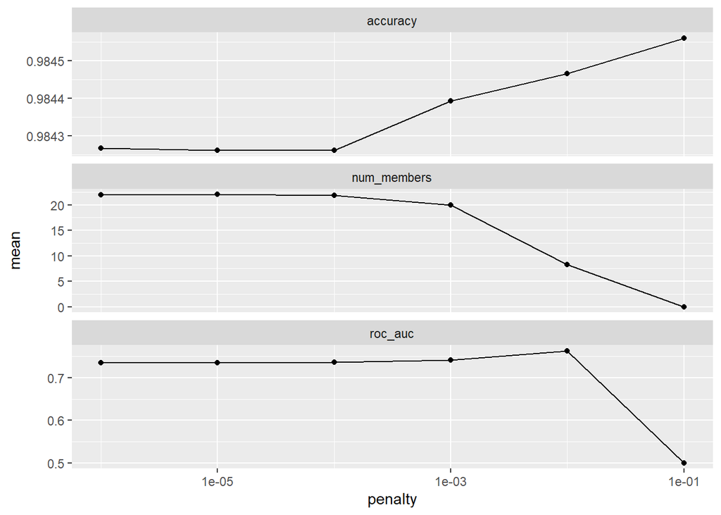

```r
autoplot(stack)
```

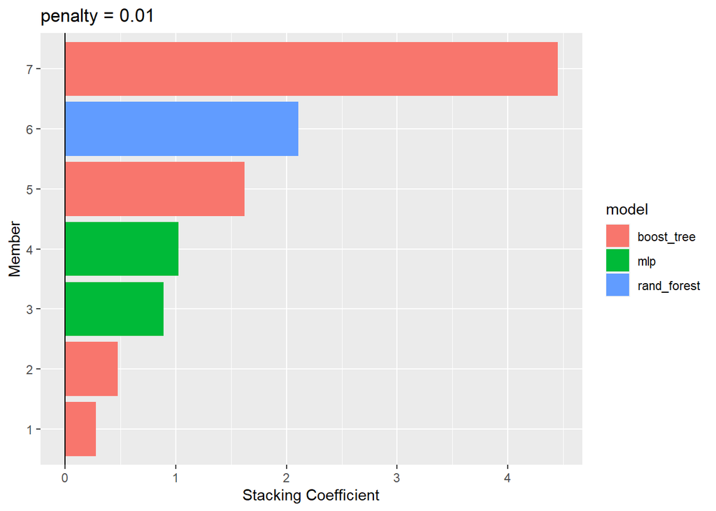

```r
autoplot(stack, type = "weights")
```

The following block of code generates the predictions, first in sample and then out of sample. I calculate their corresponding AUCs, and graph the ROCs:

```r
# In sample
stack_train_pred <- fct_rev(train$persecutions) %>% bind_cols(predict(stack, new_data = train, type = "prob")) %>%
  rename(
    persecutions = ...1,
    stack_pred = .pred_100
  ) %>%
  select(persecutions, stack_pred)
stack_train_pred %>% roc_auc(persecutions, stack_pred)
```

```
## # A tibble: 1 x 3
##   .metric .estimator .estimate
##   <chr>   <chr>          <dbl>
## 1 roc_auc binary         0.998
```

```r
# Out of sample
stack_test_pred <- fct_rev(test$persecutions) %>% bind_cols(predict(stack, new_data = test, type = "prob")) %>%
  rename(
    persecutions = ...1,
    stack_pred = .pred_100
  ) %>%
  select(persecutions, stack_pred)
stack_test_pred %>% roc_auc(persecutions, stack_pred)
```

```
## # A tibble: 1 x 3
##   .metric .estimator .estimate
##   <chr>   <chr>          <dbl>
## 1 roc_auc binary         0.721
```

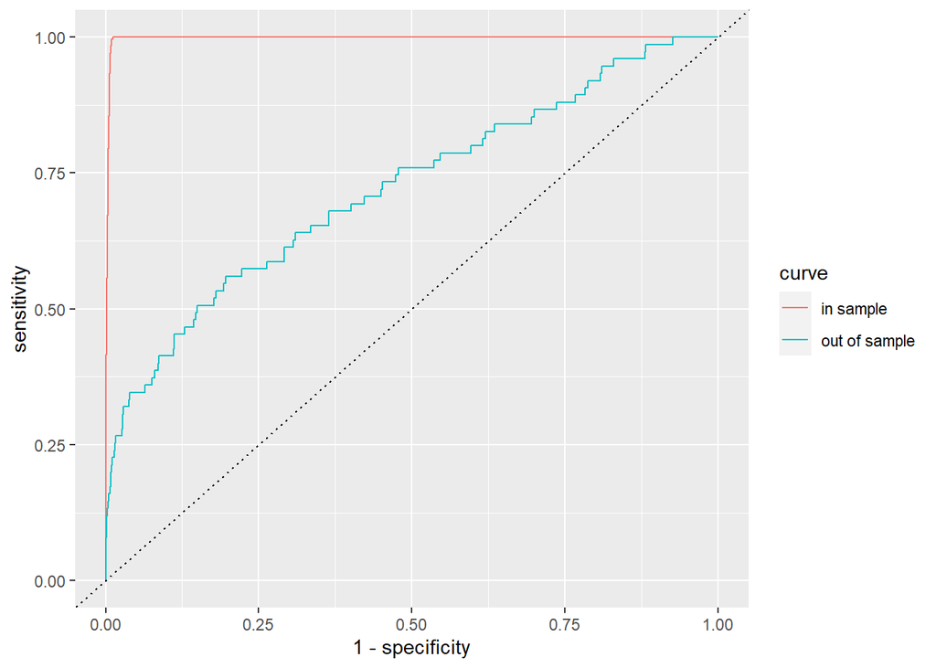

```r
# ROC curves
rbind(
  stack_train_pred %>%
    roc_curve(persecutions, stack_pred) %>%
    mutate(curve = "in sample"),
  stack_test_pred %>%
    roc_curve(persecutions, stack_pred) %>%
    mutate(curve = "out of sample")
) %>%
  ggplot(aes(x = 1 - specificity, y = sensitivity, color = curve)) +
  geom_path() +
  geom_abline(lty = 3)
```

### Reference

Anderson, Robert Warren, Noel D. Johnson, and Mark Koyama. “Jewish persecutions and weather shocks: 1100–1800.” *The Economic Journal* 127.602 (2017): 924-958.